# Contributions from iNaturalist national sites

Data analyses

Author

Florencia Grattarola

Published

September 28, 2025

The aim of this report is to give an account of the importance of the iNaturalist network members by analysing the number of records for each country.

```r
library(httr)
library(jsonlite)
library(knitr)
library(rgbif)
library(ggrepel)
library(extrafont)
library(patchwork)
library(parallel)
library(doParallel)
library(hstats)
library(vip)
library(future)
library(tidymodels)
library(tidyverse)

options(knitr.kable.NA = '')
options(scipen=999)
```

## iNaturalist National Sites

```r
iNat_network <-
  tribble(~'site', ~'site_name', ~'site_id',
        'Global', 'iNaturalist', 1,
        'Mexico', 'iNaturalistMX', 2,
        'New Zealand', 'iNaturalistNZ', 3,
        'Canada', 'iNaturalist.ca', 5,
        'Colombia', 'NaturalistaCO', 6,
        'Portugal', 'BioDiversity4All', 8,
        'Australia', 'iNaturalistAU', 9,
        'Panama', 'iNaturalistPa', 13,
        'Ecuador', 'iNaturalistEc', 14,
        'Israel', 'iNaturalistil', 15,
        'Argentina', 'ArgentiNat', 16,
        'Costa Rica', 'NaturalistaCR', 17,
        'Chile', 'iNaturalistCL', 18,
        'Finland', 'iNaturalistFi', 20,
        'Sweeden', 'iNaturalist.Se', 21,
        'Spain', 'Natusfera', 22,
        'Greece', 'iNaturalistGR', 23,
        'Guatemala', 'iNaturalistGT', 24,
        'United Kingdom', 'iNaturalistUK', 25,
        'Luxembourg', 'iNaturalist.LU', 26,
        'Taiwan', 'iNaturalistTW', 27,
        'Uruguay', 'NaturalistaUY', 28)

iNat_network %>%
  mutate('#'= row_number()) %>% relocate('#') %>%
  rename(`Site` = site,
         `Name`=site_name,
         `ID`=site_id) %>%
  kableExtra::kbl(digits=1, format.args = list(big.mark = ',')) %>%
  kableExtra::kable_material('striped') %>%
  kableExtra::row_spec(row = c(2,5,8,9,11,12,13,18,22), bold = T, color = "white", background = "#228A22")
```

Members of the iNaturalist Network. Shown in green are the sites from Latin America

| # | Site | Name | ID |
| --- | --- | --- | --- |
| 1 | Global | iNaturalist | 1 |
| 2 | Mexico | iNaturalistMX | 2 |
| 3 | New Zealand | iNaturalistNZ | 3 |
| 4 | Canada | iNaturalist.ca | 5 |
| 5 | Colombia | NaturalistaCO | 6 |
| 6 | Portugal | BioDiversity4All | 8 |
| 7 | Australia | iNaturalistAU | 9 |
| 8 | Panama | iNaturalistPa | 13 |
| 9 | Ecuador | iNaturalistEc | 14 |
| 10 | Israel | iNaturalistil | 15 |
| 11 | Argentina | ArgentiNat | 16 |
| 12 | Costa Rica | NaturalistaCR | 17 |
| 13 | Chile | iNaturalistCL | 18 |
| 14 | Finland | iNaturalistFi | 20 |
| 15 | Sweeden | iNaturalist.Se | 21 |
| 16 | Spain | Natusfera | 22 |
| 17 | Greece | iNaturalistGR | 23 |
| 18 | Guatemala | iNaturalistGT | 24 |
| 19 | United Kingdom | iNaturalistUK | 25 |
| 20 | Luxembourg | iNaturalist.LU | 26 |
| 21 | Taiwan | iNaturalistTW | 27 |
| 22 | Uruguay | NaturalistaUY | 28 |

## Methods

We tested different explanatory variables and saw which is the model that best explains the values a country has for iNaturalist. Indicators per country were extracted using the WDI: World Development Indicators (World Bank) on the **23rd of May, 2025**.

**Response variables**:

- total number of records on iNaturalist per country: `n_records_inat`.
- number of records from iNaturalist on GBIF per country (proxy for quality, research grade records): `n_records_gbif_iNat`.
- number of users recording in the country (this is not exactly the users from the country, but users that have generated records in the country): `n_users`.

**Explanatory variables**:

- population of the country: `population` (*SP.POP.TOTL*).
- area of the country in km<sup>2</sup>: `area` (*AG.SRF.TOTL.K2*).
- country’s centroid latitude (as a proxy of expected biodiversity): `latitude` (rnaturalearth).
- GDP per capita: `gdp_per_capita` (*NY.GDP.PCAP.CD*).
- % of the GDP of the country dedicated to research: `gdp_research` *GB.XPD.RSDV.GD.ZS*).

### Data extraction

**Functions**

```r
source('R/national_sites.R')
```

**Data download**

```r
UnitedStates <- tibble(country_name= 'United States')

UnitedStates <- UnitedStates %>%
  mutate(country_code = countrycode::countrycode(country_name,
                                                 origin = 'country.name',
                                                 destination = 'iso2c'))

n_inat_gbif_country <- recordsPerCountryGBIF(UnitedStates$country_code)
n_inat_country <- recordsPerCountryiNat(UnitedStates$country_name)
n_users_country <- usersPerCountryiNat(UnitedStates$country_name)
n_taxa_country <- taxaPerCountryiNat(UnitedStates$country_name)

area_country <-areaPerCountry(UnitedStates$country_code)
population <- populationPerCountry(UnitedStates$country_code)
gdp_per_capita <- gdpPerCapitaCountry(UnitedStates$country_code)
gdp_research <- gdpResearchPerCountry(UnitedStates$country_code)
latitude <- latitudePerCountry(UnitedStates$country_code)

data_variables_UnitedStates <- left_join(left_join(left_join(left_join(
  left_join(left_join(left_join(left_join(left_join(
  UnitedStates, n_inat_gbif_country),
  n_inat_country),
  n_users_country),
  n_taxa_country),
  area_country),
  population),
  gdp_per_capita),
  gdp_research), latitude)

saveRDS(data_variables_UnitedStates, 'data/UnitedStates_data_variables.rds')

########################################################################

America <- tibble(country_name= c('Canada', 'Mexico', 'Brazil', 'Costa Rica', 'Colombia', 'Peru', 'Argentina', 'Ecuador', 'Panama', 'Chile', 'Venezuela', 'Belize', 'Honduras', 'Bolivia', 'Guatemala', 'Cuba', 'Nicaragua', 'Paraguay', 'Bahamas', 'Jamaica', 'Trinidad and Tobago', 'Guyana', 'Dominican Republic', 'El Salvador', 'Suriname', 'Uruguay', 'Haiti'))

America <- America %>%
  mutate(country_code = countrycode::countrycode(country_name,
                                                 origin = 'country.name',
                                                 destination = 'iso2c'))

America <- left_join(America, iNat_network %>% rename(country_name=site))

n_inat_gbif_country <- recordsPerCountryGBIF(America$country_code)
n_inat_country <- recordsPerCountryiNat(America$country_name)
n_users_country <- usersPerCountryiNat(America$country_name)
n_taxa_country <- taxaPerCountryiNat(America$country_name)

area_country <-areaPerCountry(America$country_code)
population <- populationPerCountry(America$country_code)
gdp_per_capita <- gdpPerCapitaCountry(America$country_code)
gdp_research <- gdpResearchPerCountry(America$country_code)
latitude <- latitudePerCountry(America$country_code)

data_variables_America <- left_join(left_join(left_join(left_join(
  left_join(left_join(left_join(left_join(left_join(
  America, n_inat_gbif_country),
  n_inat_country),
  n_users_country),
  n_taxa_country),
  area_country),
  population),
  gdp_per_capita),
  gdp_research), latitude)

saveRDS(data_variables_America, 'data/America_data_variables.rds')

########################################################################

Europe <- tibble(country_name = c('Austria', 'Belgium', 'Bulgaria', 'Croatia', 'Cyprus', 'Czechia', 'Denmark', 'Estonia', 'Finland', 'France', 'Germany', 'Greece', 'Hungary', 'Ireland', 'Italy', 'Latvia', 'Lithuania', 'Luxembourg', 'Malta', 'Netherlands', 'Poland', 'Portugal', 'Romania', 'Slovakia', 'Slovenia', 'Spain', 'Sweden', 'United Kingdom', 'Iceland', 'Liechtenstein', 'Norway', 'Switzerland', 'Albania', 'Bosnia and Herzegovina', 'Georgia', 'Moldova', 'Montenegro', 'Macedonia', 'Serbia', 'Turkey', 'Ukraine'))

Europe <- Europe %>%
  mutate(country_code = countrycode::countrycode(country_name,
                                                 origin = 'country.name',
                                                 destination = 'iso2c'))

Europe <- left_join(Europe, iNat_network %>% rename(country_name=site))

n_inat_gbif_country <- recordsPerCountryGBIF(Europe$country_code)
n_inat_country <- recordsPerCountryiNat(Europe$country_name)
n_users_country <- usersPerCountryiNat(Europe$country_name)
n_taxa_country <- taxaPerCountryiNat(Europe$country_name)

area_country <-areaPerCountry(Europe$country_code)
population <- populationPerCountry(Europe$country_code)
gdp_per_capita <- gdpPerCapitaCountry(Europe$country_code)
gdp_research <- gdpResearchPerCountry(Europe$country_code)
latitude <- latitudePerCountry(Europe$country_code)

data_variables_Europe <- left_join(left_join(left_join(left_join(
  left_join(left_join(left_join(left_join(left_join(
  Europe, n_inat_gbif_country),
  n_inat_country),
  n_users_country),
  n_taxa_country),
  area_country),
  population),
  gdp_per_capita),
  gdp_research), latitude)

saveRDS(data_variables_Europe, 'data/Europe_data_variables.rds')

########################################################################

Asia <- tibble(country_name = c('India', 'China', 'Indonesia', 'Pakistan', 'Bangladesh', 'Japan', 'Philippines', 'Vietnam', 'Iran', 'Turkey', 'Thailand', 'Myanmar', 'South Korea','Iraq', 'Afghanistan', 'Yemen', 'Uzbekistan', 'Malaysia', 'Saudi Arabia', 'Nepal', 'North Korea','Syria', 'Sri Lanka','Kazakhstan', 'Cambodia', 'Jordan', 'United Arab Emirates', 'Tajikistan', 'Azerbaijan', 'Israel', 'Laos', 'Turkmenistan', 'Kyrgyzstan', 'Singapore', 'Lebanon', 'Palestine','Oman', 'Kuwait', 'Georgia', 'Mongolia', 'Qatar', 'Armenia', 'Bahrain', 'Timor Leste', 'Cyprus', 'Bhutan', 'Maldives', 'Brunei', 'Taiwan'))

Asia <- Asia %>%
  mutate(country_code = countrycode::countrycode(country_name,
                                                 origin = 'country.name',
                                                 destination = 'iso2c'))

Asia <- left_join(Asia, iNat_network %>% rename(country_name=site))

n_inat_gbif_country <- recordsPerCountryGBIF(Asia$country_code)
n_inat_country <- recordsPerCountryiNat(Asia$country_name)
n_users_country <- usersPerCountryiNat(Asia$country_name)
n_taxa_country <- taxaPerCountryiNat(Asia$country_name)

area_country <-areaPerCountry(Asia$country_code)
population <- populationPerCountry(Asia$country_code)
gdp_per_capita <- gdpPerCapitaCountry(Asia$country_code)
gdp_research <- gdpResearchPerCountry(Asia$country_code)
latitude <- latitudePerCountry(Asia$country_code)

data_variables_Asia <- left_join(left_join(left_join(left_join(
  left_join(left_join(left_join(left_join(left_join(
  Asia, n_inat_gbif_country),
  n_inat_country),
  n_users_country),
  n_taxa_country),
  area_country),
  population),
  gdp_per_capita),
  gdp_research), latitude)

data_variables_Asia <- data_variables_Asia %>%
  mutate(area = ifelse(country_name == 'Taiwan', 36197, area),
         pop = ifelse(country_name == 'Taiwan', 23365274, pop))

saveRDS(data_variables_Asia, 'data/Asia_data_variables.rds')

########################################################################

Oceania <- tibble(country_name = c('Australia', 'Papua New Guinea', 'New Zealand', 'Fiji', 'Solomon Islands', 'Federated States of Micronesia', 'Vanuatu', 'Samoa', 'Kiribati', 'Tonga', 'Marshall Islands', 'Palau', 'Tuvalu', 'Nauru'))

Oceania <- Oceania %>%
  mutate(country_code = countrycode::countrycode(country_name,
                                                 origin = 'country.name',
                                                 destination = 'iso2c'))

Oceania <- left_join(Oceania, iNat_network %>% rename(country_name=site))

n_inat_gbif_country <- recordsPerCountryGBIF(Oceania$country_code)
n_inat_country <- recordsPerCountryiNat(Oceania$country_name)
n_users_country <- usersPerCountryiNat(Oceania$country_name)
n_taxa_country <- taxaPerCountryiNat(Oceania$country_name)

area_country <-areaPerCountry(Oceania$country_code)
population <- populationPerCountry(Oceania$country_code)
gdp_per_capita <- gdpPerCapitaCountry(Oceania$country_code)
gdp_research <- gdpResearchPerCountry(Oceania$country_code)
latitude <- latitudePerCountry(Oceania$country_code)

data_variables_Oceania <- left_join(left_join(left_join(left_join(
  left_join(left_join(left_join(left_join(left_join(
  Oceania, n_inat_gbif_country),
  n_inat_country),
  n_users_country),
  n_taxa_country),
  area_country),
  population),
  gdp_per_capita),
  gdp_research), latitude)

saveRDS(data_variables_Oceania, 'data/Oceania_data_variables.rds')

########################################################################

variables_global <- bind_rows(data_variables_UnitedStates %>%
                                mutate(continent = 'America'),
                              data_variables_America %>%
                                mutate(continent = 'America'),
                              data_variables_Europe %>%
                                mutate(continent = 'Europe'),
                              data_variables_Asia %>%
                                mutate(continent = 'Asia'),
                              data_variables_Oceania %>%
                                mutate(continent = 'Oceania')) %>%
  unique()

# variables_global <- bind_rows(readRDS('data/UnitedStates_data_variables.rds') %>%
#                                 mutate(continent = 'America'),
#   readRDS('data/America_data_variables.rds') %>%
#                                 mutate(continent = 'America'),
#           readRDS('data/Europe_data_variables.rds') %>%
#                                 mutate(continent = 'Europe'),
#           readRDS('data/Asia_data_variables.rds') %>%
#                                 mutate(continent = 'Asia'),
#           readRDS('data/Oceania_data_variables.rds') %>%
#                                 mutate(continent = 'Oceania'))  %>%
#   unique()

saveRDS(variables_global, 'data/global_data_variables.rds')
```

## Summary of the data for the Network members

### Total number of records on iNaturalist per country

```r
ids <- data_variables %>%
  select(country_name,site_name, n_records_inat) %>%
  arrange(desc(n_records_inat)) %>%
  with(which(!is.na(site_name)))

data_variables %>%
  select(country_name,site_name, n_records_inat) %>%
  arrange(desc(n_records_inat)) %>%
  mutate('#'= row_number()) %>% relocate('#') %>%
  rename(`Country` = country_name,
         `iNat site` = site_name,
         `Records on iNat`=n_records_inat) %>%
  kableExtra::kbl(digits=4, format.args = list(big.mark = ',')) %>%
  kableExtra::kable_material('striped') %>%
  kableExtra::row_spec(ids, bold = T, color = "white", background = "#228A22") %>%
  kableExtra::scroll_box(height = '600px')
```

| # | Country | iNat site | Records on iNat |
| --- | --- | --- | --- |
| 1 | United States |  | 117,967,387 |
| 2 | Canada | iNaturalist.ca | 20,889,613 |
| 3 | Australia | iNaturalistAU | 11,976,616 |
| 4 | Mexico | iNaturalistMX | 8,975,015 |
| 5 | United Kingdom | iNaturalistUK | 8,141,711 |
| 6 | Germany |  | 6,081,430 |
| 7 | France |  | 5,749,959 |
| 8 | Spain | Natusfera | 5,162,544 |
| 9 | Italy |  | 4,147,436 |
| 10 | Taiwan | iNaturalistTW | 4,052,959 |
| 11 | India |  | 4,013,726 |
| 12 | Brazil |  | 3,829,606 |
| 13 | New Zealand | iNaturalistNZ | 3,148,237 |
| 14 | Austria |  | 2,935,237 |
| 15 | Portugal | BioDiversity4All | 2,332,457 |
| 16 | China |  | 2,042,227 |
| 17 | Colombia | NaturalistaCO | 2,040,943 |
| 18 | Ecuador | iNaturalistEc | 2,024,022 |
| 19 | Argentina | ArgentiNat | 1,926,013 |
| 20 | Ukraine |  | 1,875,798 |
| 21 | Denmark |  | 1,854,729 |
| 22 | Costa Rica | NaturalistaCR | 1,764,500 |
| 23 | Poland |  | 1,584,642 |
| 24 | Czechia |  | 1,487,638 |
| 25 | Finland | iNaturalistFi | 1,424,762 |
| 26 | Japan |  | 1,156,139 |
| 27 | Thailand |  | 1,108,651 |
| 28 | Malaysia |  | 1,092,232 |
| 29 | Netherlands |  | 1,083,404 |
| 30 | Indonesia |  | 1,071,014 |

[output cut: 102 more lines]

### Number of records from iNaturalist on GBIF per country

```r
ids <- data_variables %>%
  select(country_name, site_name, n_records_gbif, n_records_gbif_iNat) %>%
  mutate(proportion=n_records_gbif_iNat*100/n_records_gbif) %>%
  arrange(desc(proportion)) %>%
  with(which(!is.na(site_name)))

data_variables %>%
  select(country_name, site_name, n_records_gbif, n_records_gbif_iNat) %>%
  mutate(proportion=n_records_gbif_iNat*100/n_records_gbif) %>%
  arrange(desc(proportion)) %>%
  mutate('#'= row_number()) %>% relocate('#') %>%
  select(-n_records_gbif_iNat) %>%
  rename(`Country` = country_name,
         `iNat site` = site_name,
         `Records from iNat on GBIF`=n_records_gbif,
         `Proportion`=proportion) %>%
  kableExtra::kbl(digits=4, format.args = list(big.mark = ',')) %>%
  kableExtra::kable_material('striped') %>%
  kableExtra::row_spec(ids, bold = T, color = "white", background = "#228A22") %>%
  kableExtra::scroll_box(height = '600px')
```

| # | Country | iNat site | Records from iNat on GBIF | Proportion |
| --- | --- | --- | --- | --- |
| 1 | Maldives |  | 108,822 | 28.6808 |
| 2 | Ukraine |  | 3,931,831 | 27.5579 |
| 3 | Albania |  | 144,430 | 22.7903 |
| 4 | Italy |  | 8,596,699 | 21.9913 |
| 5 | Kazakhstan |  | 539,075 | 21.7589 |
| 6 | Singapore |  | 1,974,945 | 20.2467 |
| 7 | Croatia |  | 1,274,969 | 19.0917 |
| 8 | Tuvalu |  | 9,776 | 18.9546 |
| 9 | Montenegro |  | 174,675 | 18.8745 |
| 10 | Bosnia and Herzegovina |  | 98,561 | 17.4674 |
| 11 | Malta |  | 99,495 | 16.9767 |
| 12 | Lithuania |  | 1,479,823 | 16.4623 |
| 13 | Uzbekistan |  | 148,530 | 15.3498 |
| 14 | Fiji |  | 307,778 | 14.7860 |
| 15 | Hungary |  | 2,226,224 | 13.2507 |
| 16 | Marshall Islands |  | 120,862 | 13.0322 |
| 17 | Czechia |  | 5,318,179 | 11.9122 |
| 18 | Slovenia |  | 921,600 | 11.8601 |
| 19 | New Zealand | iNaturalistNZ | 16,738,367 | 11.7287 |
| 20 | Indonesia |  | 3,461,778 | 11.7265 |
| 21 | Austria |  | 15,651,302 | 11.1046 |
| 22 | Timor Leste |  | 97,706 | 11.0812 |
| 23 | Greece | iNaturalistGR | 4,019,188 | 10.3777 |
| 24 | Mexico | iNaturalistMX | 35,031,471 | 9.9170 |
| 25 | Armenia |  | 242,972 | 9.8859 |
| 26 | Romania |  | 1,476,087 | 9.8087 |
| 27 | Iraq |  | 76,252 | 9.5447 |
| 28 | Mongolia |  | 682,658 | 8.5092 |
| 29 | Malaysia |  | 3,807,247 | 8.0152 |
| 30 | Slovakia |  | 1,921,795 | 7.7925 |

[output cut: 102 more lines]

### Number of users recording in the country

```r
ids <- data_variables %>%
  select(country_name, site_name, n_users) %>%
  arrange(desc(n_users)) %>%
  with(which(!is.na(site_name)))

data_variables %>%
  select(country_name, site_name, n_users) %>%
  arrange(desc(n_users)) %>%
  mutate('#'= row_number()) %>% relocate('#') %>%
  rename(`Country` = country_name,
         `iNat site` = site_name,
         `Users recording on iNat`=n_users) %>%
  kableExtra::kbl(digits=4, format.args = list(big.mark = ',')) %>%
  kableExtra::kable_material('striped') %>%
  kableExtra::row_spec(ids, bold = T, color = "white", background = "#228A22") %>%
  kableExtra::scroll_box(height = '600px')
```

| # | Country | iNat site | Users recording on iNat |
| --- | --- | --- | --- |
| 1 | United States |  | 1,934,413 |
| 2 | Canada | iNaturalist.ca | 271,433 |
| 3 | Mexico | iNaturalistMX | 176,834 |
| 4 | United Kingdom | iNaturalistUK | 157,683 |
| 5 | France |  | 138,493 |
| 6 | Australia | iNaturalistAU | 125,027 |
| 7 | Italy |  | 94,972 |
| 8 | Germany |  | 89,923 |
| 9 | Spain | Natusfera | 82,474 |
| 10 | Denmark |  | 77,749 |
| 11 | Brazil |  | 74,949 |
| 12 | Taiwan | iNaturalistTW | 61,961 |
| 13 | Colombia | NaturalistaCO | 58,511 |
| 14 | India |  | 51,941 |
| 15 | New Zealand | iNaturalistNZ | 48,690 |
| 16 | Portugal | BioDiversity4All | 39,586 |
| 17 | Ecuador | iNaturalistEc | 38,941 |
| 18 | Costa Rica | NaturalistaCR | 38,826 |
| 19 | Czechia |  | 36,676 |
| 20 | Austria |  | 32,866 |
| 21 | Netherlands |  | 32,226 |
| 22 | Finland | iNaturalistFi | 31,699 |
| 23 | Bolivia |  | 28,519 |
| 24 | Belgium |  | 26,335 |
| 25 | Japan |  | 25,935 |
| 26 | Argentina | ArgentiNat | 25,924 |
| 27 | Thailand |  | 24,844 |
| 28 | Switzerland |  | 24,368 |
| 29 | Indonesia |  | 24,235 |
| 30 | Chile | iNaturalistCL | 24,136 |

[output cut: 102 more lines]

## Associations between variables

### Population of the country

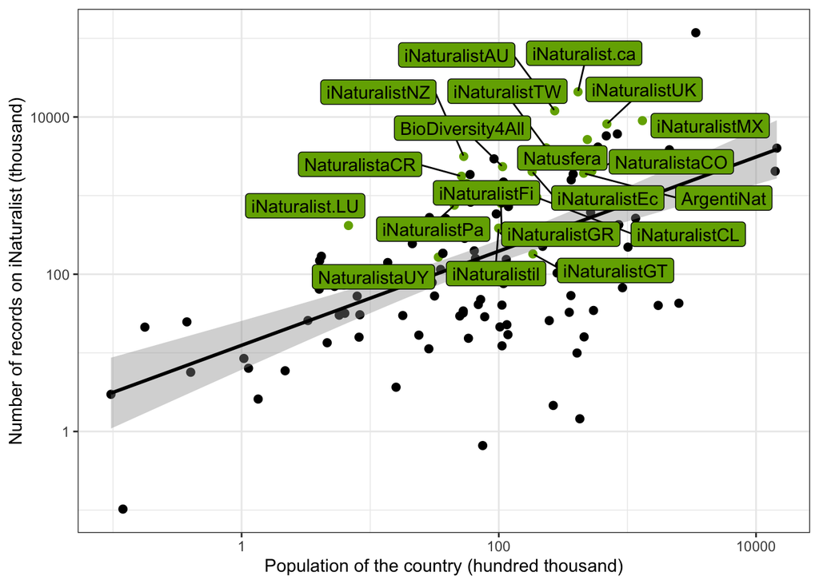

Number of records on iNaturalist vs Population of the country

```r
## records
ggplot(data_variables %>% mutate(site_on_iNat = ifelse(!is.na(site_id), 'yes', 'no')),
       aes(pop/100000, n_records_inat/1000, label = site_name)) +
  geom_point(aes(col=site_on_iNat), size=2, show.legend = F) +
  scale_color_manual(values = c('black', '#74AC00')) +
  geom_smooth(method='lm', colour = 'black') +
  geom_label_repel(aes(fill=site_on_iNat),
                   colour = "black", #fontface = "bold",
                   segment.color = 'black',
                   show.legend = F, max.overlaps= Inf) +
  scale_fill_manual(values = c('#F7F7F7', '#74AC00')) +
  labs(x='Population of the country (hundred thousand)',
       y='Number of records on iNaturalist (thousand)') +
  scale_x_log10() + scale_y_log10() +
  theme_bw()
```

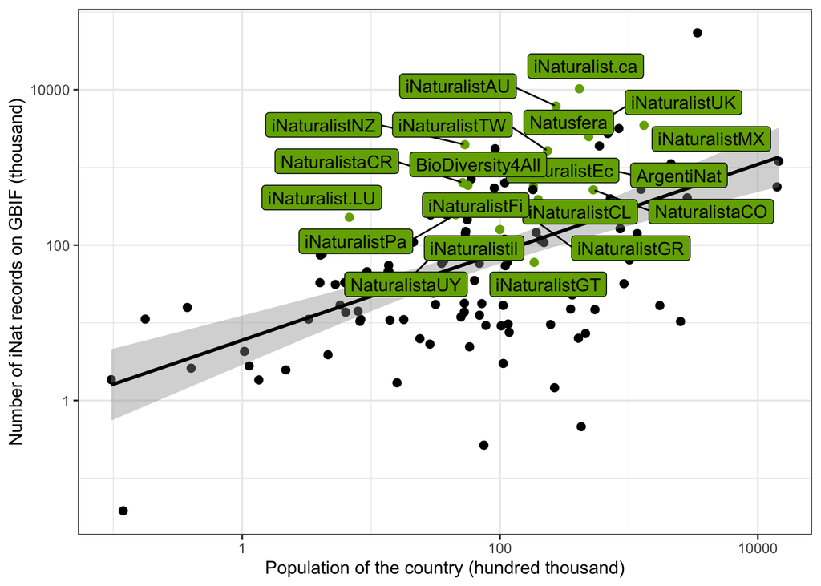

Number of iNat records on GBIF vs Population of the country

```r
## records in GBIF
ggplot(data_variables %>% mutate(site_on_iNat = ifelse(!is.na(site_id), 'yes', 'no')),
       aes(pop/100000, n_records_gbif_iNat/1000, label = site_name)) +
  geom_point(aes(col=site_on_iNat), size=2, show.legend = F) +
  scale_color_manual(values = c('black', '#74AC00')) +
  geom_smooth(method='lm', colour = 'black') +
  geom_label_repel(aes(fill=site_on_iNat),
                   colour = "black", #fontface = "bold",
                   segment.color = 'black',
                   show.legend = F, max.overlaps= Inf) +
  scale_fill_manual(values = c('#F7F7F7', '#74AC00')) +
  labs(x='Population of the country (hundred thousand)',
       y='Number of iNat records on GBIF (thousand)') +
  scale_x_log10() + scale_y_log10() +
  theme_bw()
```

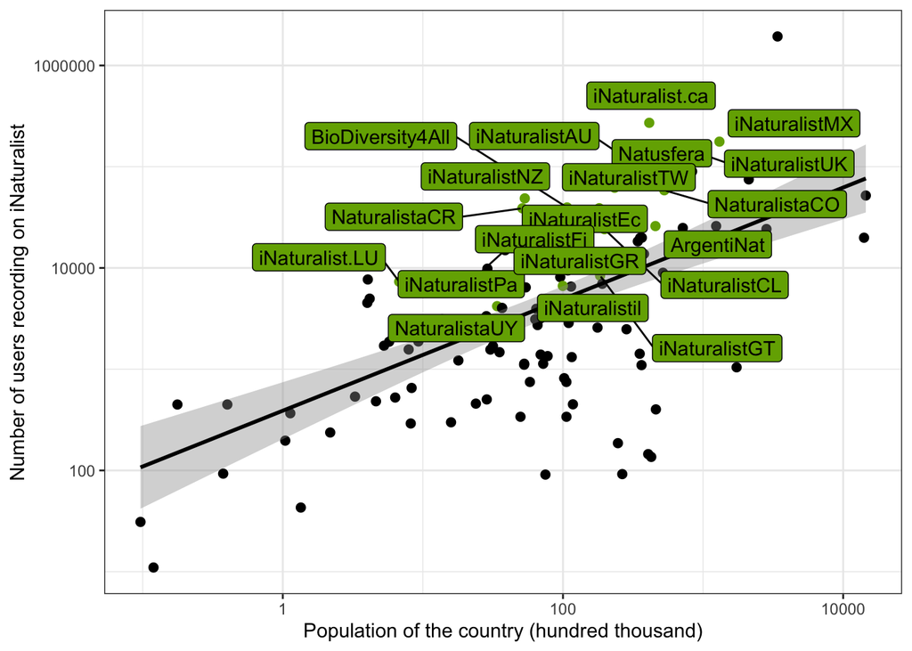

Number of users recording on iNaturalist vs Population of the country

```r
## users
ggplot(data_variables %>% mutate(site_on_iNat = ifelse(!is.na(site_id), 'yes', 'no')),
       aes(pop/100000, n_users, label = site_name)) +
  geom_point(aes(col=site_on_iNat), size=2, show.legend = F) +
  scale_color_manual(values = c('black', '#74AC00')) +
  geom_smooth(method='lm', col= 'black') +
  geom_label_repel(aes(fill=site_on_iNat),
                   colour = "black", #fontface = "bold",
                   segment.color = 'black',
                   show.legend = F, max.overlaps= Inf) +
  scale_fill_manual(values = c('#F7F7F7', '#74AC00')) +
  labs(x='Population of the country (hundred thousand)',
       y='Number of users recording on iNaturalist') +
  scale_x_log10() + scale_y_log10() +
  theme_bw()
```

### Area of the country in km<sup>2</sup>

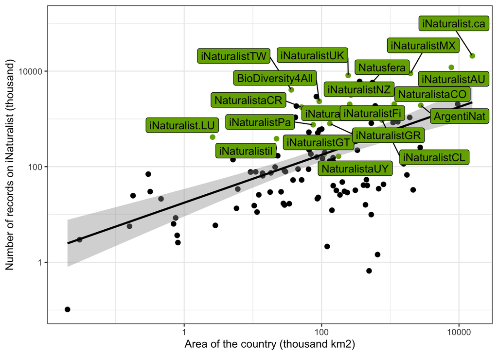

Number of records on iNaturalist vs Area of the country

```r
## records
ggplot(data_variables %>% mutate(site_on_iNat = ifelse(!is.na(site_id), 'yes', 'no')),
       aes(area/1000,n_records_inat/1000, label = site_name)) +
  geom_point(aes(col=site_on_iNat), size=2, show.legend = F) +
  scale_color_manual(values = c('black', '#74AC00')) +
  geom_smooth(method='lm', colour = 'black') +
  geom_label_repel(aes(fill=site_on_iNat),
                   colour = "black", #fontface = "bold",
                   segment.color = 'black',
                   show.legend = F, max.overlaps= Inf) +
  scale_fill_manual(values = c('#F7F7F7', '#74AC00')) +
  labs(x='Area of the country (thousand km2)',
       y='Number of records on iNaturalist (thousand)') +
  scale_x_log10() + scale_y_log10() +
  theme_bw()
```

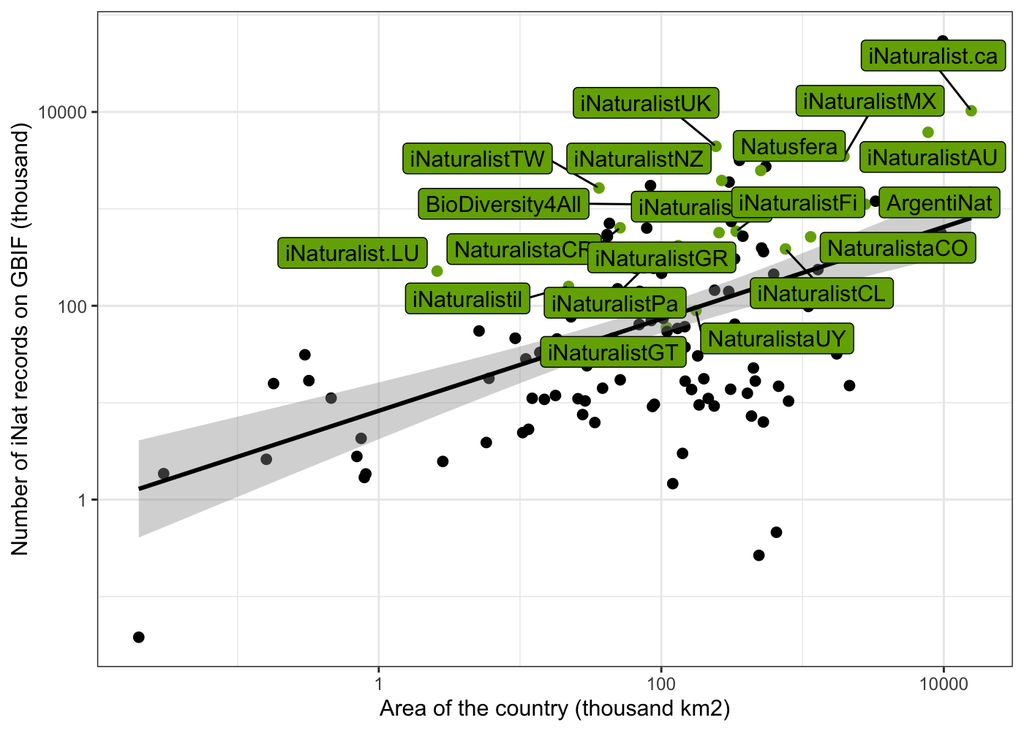

Number of iNat records on GBIF vs Area of the country

```r
## records in gbif
ggplot(data_variables %>% mutate(site_on_iNat = ifelse(!is.na(site_id), 'yes', 'no')),
       aes(area/1000, n_records_gbif_iNat/1000, label = site_name)) +
  geom_point(aes(col=site_on_iNat), size=2, show.legend = F) +
  scale_color_manual(values = c('black', '#74AC00')) +
  geom_smooth(method='lm', colour = 'black') +
  geom_label_repel(aes(fill=site_on_iNat),
                   colour = "black", #fontface = "bold",
                   segment.color = 'black',
                   show.legend = F, max.overlaps= Inf) +
  scale_fill_manual(values = c('#F7F7F7', '#74AC00')) +
  labs(x='Area of the country (thousand km2)',
       y='Number of iNat records on GBIF (thousand)') +
  scale_x_log10() + scale_y_log10() +
  theme_bw()
```

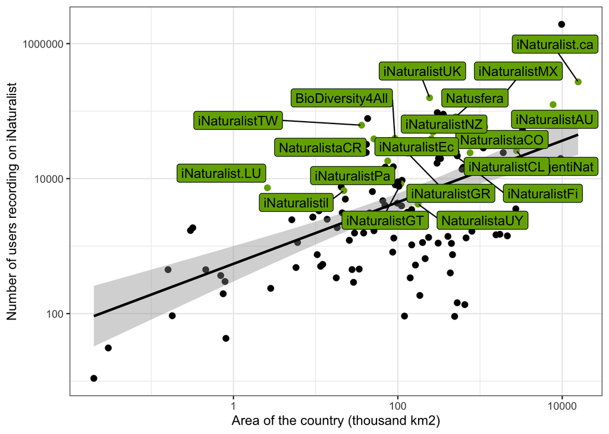

Number of users recording on iNaturalist vs Area of the country

```r
## users
ggplot(data_variables %>% mutate(site_on_iNat = ifelse(!is.na(site_id), 'yes', 'no')),
       aes(area/1000, n_users, label = site_name)) +
  geom_point(aes(col=site_on_iNat), size=2, show.legend = F) +
  scale_color_manual(values = c('black', '#74AC00')) +
  geom_smooth(method='lm', colour = 'black') +
  geom_label_repel(aes(fill=site_on_iNat),
                   colour = "black", #fontface = "bold",
                   segment.color = 'black',
                   show.legend = F, max.overlaps= Inf) +
  scale_fill_manual(values = c('#F7F7F7', '#74AC00')) +
  labs(x='Area of the country (thousand km2)',
       y='Number of users recording on iNaturalist') +
  scale_x_log10() + scale_y_log10() +
  theme_bw()
```

### Country’s centroid latitude

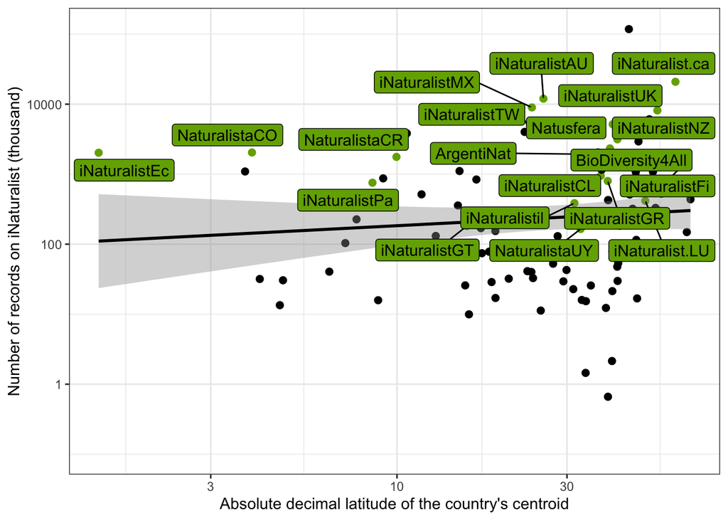

Number of records on iNaturalist vs country’s centroid latitude

```r
## records
ggplot(data_variables %>% mutate(site_on_iNat = ifelse(!is.na(site_id), 'yes', 'no')),
       aes(abs(latitude), n_records_inat/1000, label = site_name)) +
  geom_point(aes(col=site_on_iNat), size=2, show.legend = F) +
  scale_color_manual(values = c('black', '#74AC00')) +
  geom_smooth(method='lm', colour = 'black') +
  geom_label_repel(aes(fill=site_on_iNat),
                   colour = "black", #fontface = "bold",
                   segment.color = 'black',
                   show.legend = F, max.overlaps= Inf) +
  scale_fill_manual(values = c('#F7F7F7', '#74AC00')) +
  labs(x='Absolute decimal latitude of the country\'s centroid',
       y='Number of records on iNaturalist (thousand)') +
  scale_x_log10() + scale_y_log10() +
  theme_bw()
```

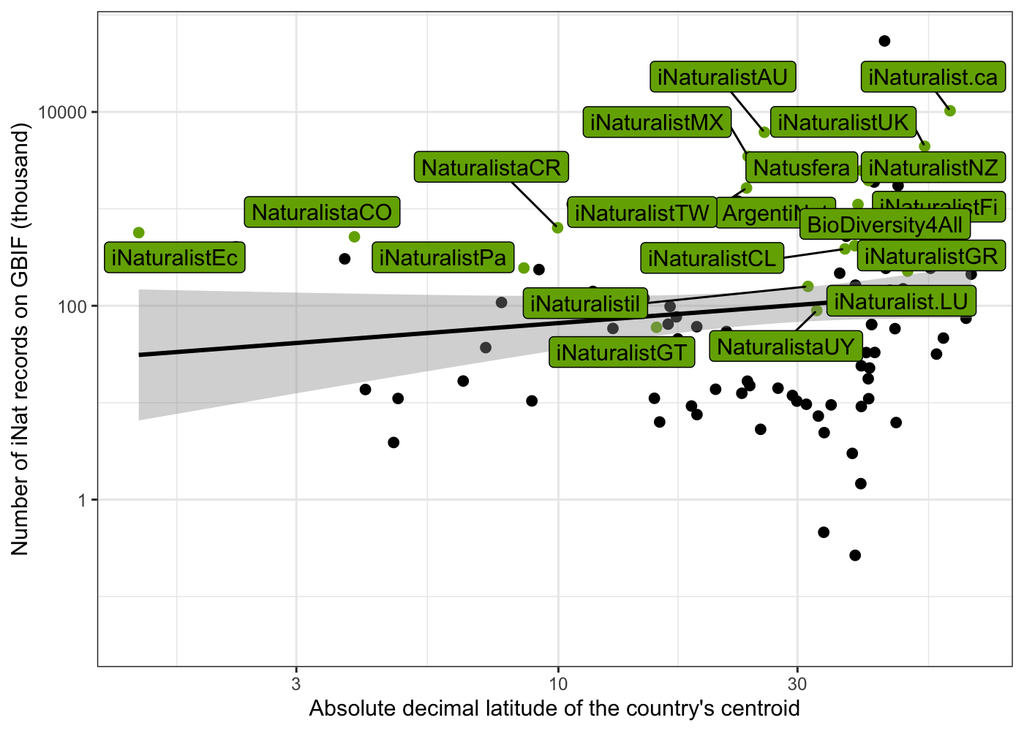

Number of iNat records on GBIF vs country’s centroid latitude

```r
## records in gbif
ggplot(data_variables %>% mutate(site_on_iNat = ifelse(!is.na(site_id), 'yes', 'no')),
       aes(abs(latitude), n_records_gbif_iNat/1000, label = site_name)) +
  geom_point(aes(col=site_on_iNat), size=2, show.legend = F) +
  scale_color_manual(values = c('black', '#74AC00')) +
  geom_smooth(method='lm', colour = 'black') +
  geom_label_repel(aes(fill=site_on_iNat),
                   colour = "black", #fontface = "bold",
                   segment.color = 'black',
                   show.legend = F, max.overlaps= Inf) +
  scale_fill_manual(values = c('#F7F7F7', '#74AC00')) +
  labs(x='Absolute decimal latitude of the country\'s centroid',
       y='Number of iNat records on GBIF (thousand)') +
  scale_x_log10() + scale_y_log10() +
  theme_bw()
```

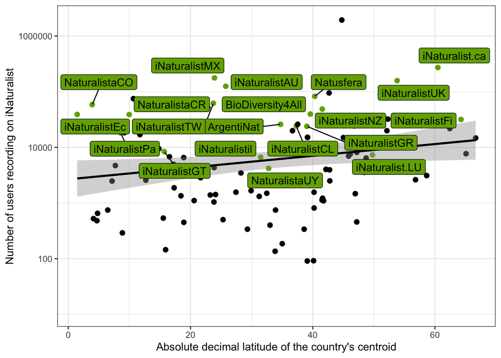

Number of users recording on iNaturalist vs country’s centroid latitude

```r
## users
ggplot(data_variables %>%
         mutate(site_on_iNat = ifelse(!is.na(site_id), 'yes', 'no')),
       aes(abs(latitude), n_users, label = site_name)) +
  geom_point(aes(col=site_on_iNat), size=2, show.legend = F) +
  scale_color_manual(values = c('black', '#74AC00')) +
  geom_smooth(method='lm', colour = 'black') +
  geom_label_repel(aes(fill=site_on_iNat),
                   colour = "black", #fontface = "bold",
                   segment.color = 'black',
                   show.legend = F, max.overlaps= Inf) +
  scale_fill_manual(values = c('#F7F7F7', '#74AC00')) +
  labs(x='Absolute decimal latitude of the country\'s centroid',
       y='Number of users recording on iNaturalist') +
  #scale_x_log10() +
  scale_y_log10() +
  theme_bw()
```

### GDP per capita

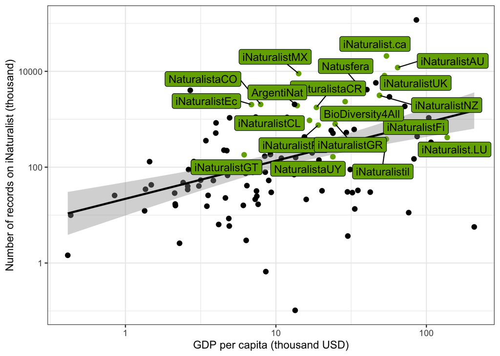

Number of records on iNaturalist vs country’s GDP per capita

```r
## records
ggplot(data_variables %>% mutate(site_on_iNat = ifelse(!is.na(site_id), 'yes', 'no')),
       aes(gdp/1000, n_records_inat/1000, label = site_name)) +
  geom_point(aes(col=site_on_iNat), size=2, show.legend = F) +
  scale_color_manual(values = c('black', '#74AC00')) +
  geom_smooth(method='lm', colour = 'black') +
  geom_label_repel(aes(fill=site_on_iNat),
                   colour = "black", #fontface = "bold",
                   segment.color = 'black',
                   show.legend = F, max.overlaps= Inf) +
  scale_fill_manual(values = c('#F7F7F7', '#74AC00')) +
  labs(x='GDP per capita (thousand USD)',
       y='Number of records on iNaturalist (thousand)') +
  scale_x_log10() + scale_y_log10() +
  theme_bw()
```

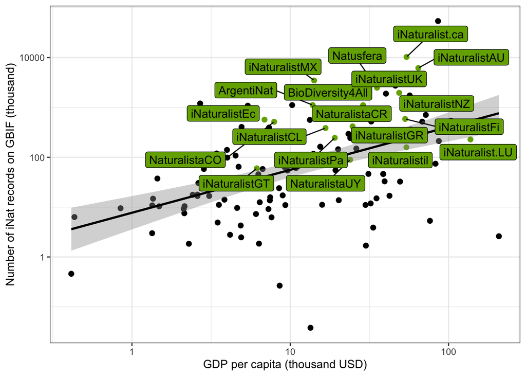

Number of iNat records on GBIF vs country’s GDP per capita

```r
## records in gbif
ggplot(data_variables %>% mutate(site_on_iNat = ifelse(!is.na(site_id), 'yes', 'no')),
       aes(gdp/1000, n_records_gbif_iNat/1000, label = site_name)) +
  geom_point(aes(col=site_on_iNat), size=2, show.legend = F) +
  scale_color_manual(values = c('black', '#74AC00')) +
  geom_smooth(method='lm', colour = 'black') +
  geom_label_repel(aes(fill=site_on_iNat),
                   colour = "black", #fontface = "bold",
                   segment.color = 'black',
                   show.legend = F, max.overlaps= Inf) +
  scale_fill_manual(values = c('#F7F7F7', '#74AC00')) +
  labs(x='GDP per capita (thousand USD)',
       y='Number of iNat records on GBIF (thousand)') +
  scale_x_log10() + scale_y_log10() +
  theme_bw()
```

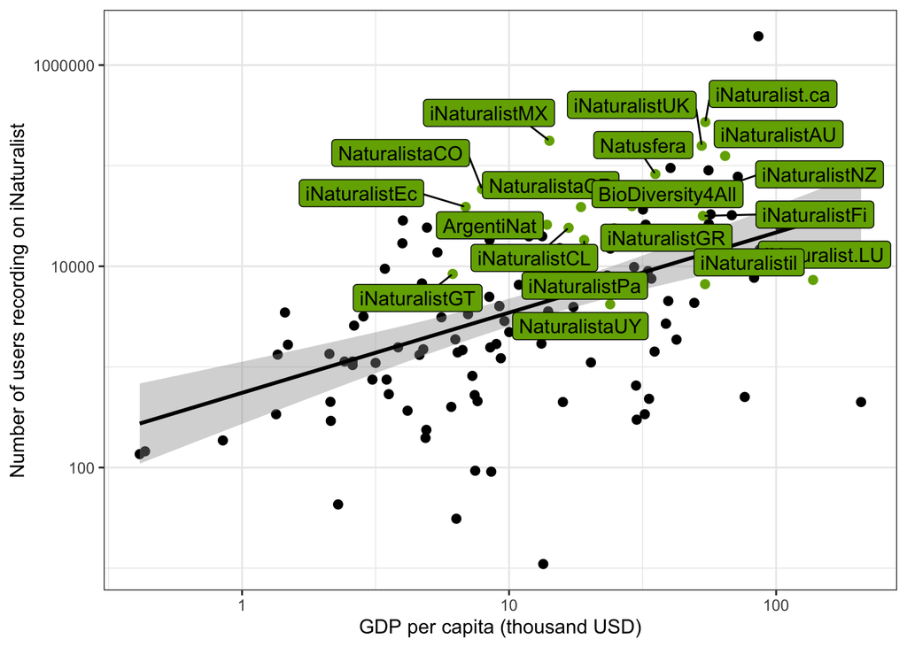

Number of users recording on iNaturalist vs GDP per capita

```r
## users
ggplot(data_variables %>%
         mutate(site_on_iNat = ifelse(!is.na(site_id), 'yes', 'no')),
       aes(gdp/1000, n_users, label = site_name)) +
  geom_point(aes(col=site_on_iNat), size=2, show.legend = F) +
  scale_color_manual(values = c('black', '#74AC00')) +
  geom_smooth(method='lm', colour = 'black') +
  geom_label_repel(aes(fill=site_on_iNat),
                   colour = "black", #fontface = "bold",
                   segment.color = 'black',
                   show.legend = F, max.overlaps= Inf) +
  scale_fill_manual(values = c('#F7F7F7', '#74AC00')) +
  labs(x='GDP per capita (thousand USD)',
       y='Number of users recording on iNaturalist') +
  scale_x_log10() + scale_y_log10() +
  theme_bw()
```

### % of the GDP of the country dedicated to research

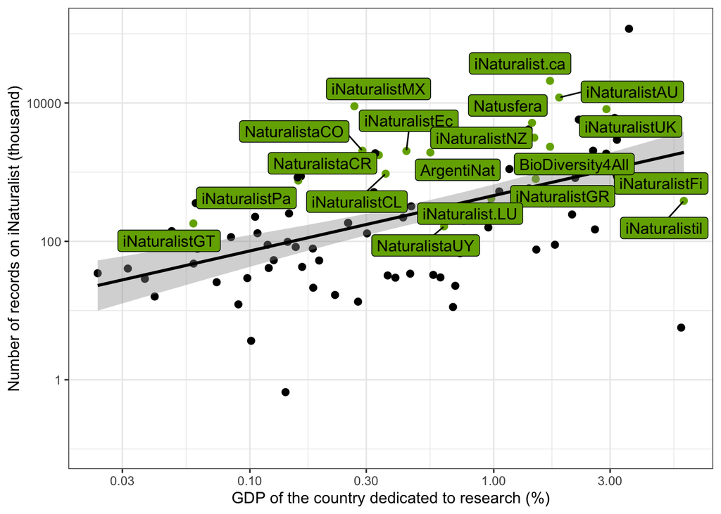

Number of records on iNaturalist vs % of the country’s GDP dedicated to research

```r
## records
ggplot(data_variables %>% mutate(site_on_iNat = ifelse(!is.na(site_id), 'yes', 'no')),
       aes(gdp_research, n_records_inat/1000, label = site_name)) +
  geom_point(aes(col=site_on_iNat), size=2, show.legend = F) +
  scale_color_manual(values = c('black', '#74AC00')) +
  geom_smooth(method='lm', colour = 'black') +
  geom_label_repel(aes(fill=site_on_iNat),
                   colour = "black", #fontface = "bold",
                   segment.color = 'black',
                   show.legend = F, max.overlaps= Inf) +
  scale_fill_manual(values = c('#F7F7F7', '#74AC00')) +
  labs(x='GDP of the country dedicated to research (%)',
       y='Number of records on iNaturalist (thousand)') +
  scale_x_log10() + scale_y_log10() +
  theme_bw()
```

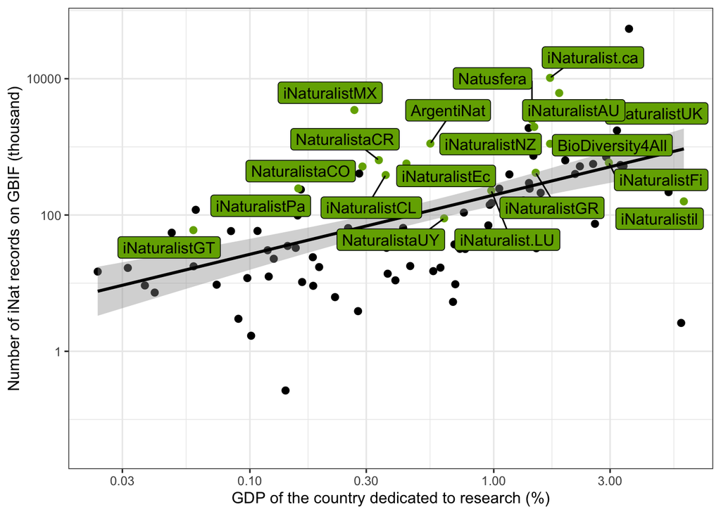

Number of iNat records on GBIF vs % of the country’s GDP dedicated to research

```r
## records in gbif
ggplot(data_variables %>% mutate(site_on_iNat = ifelse(!is.na(site_id), 'yes', 'no')),
       aes(gdp_research, n_records_gbif_iNat/1000, label = site_name)) +
  geom_point(aes(col=site_on_iNat), size=2, show.legend = F) +
  scale_color_manual(values = c('black', '#74AC00')) +
  geom_smooth(method='lm', colour = 'black') +
  geom_label_repel(aes(fill=site_on_iNat),
                   colour = "black", #fontface = "bold",
                   segment.color = 'black',
                   show.legend = F, max.overlaps= Inf) +
  scale_fill_manual(values = c('#F7F7F7', '#74AC00')) +
  labs(x='GDP of the country dedicated to research (%)',
       y='Number of iNat records on GBIF (thousand)') +
  scale_x_log10() + scale_y_log10() +
  theme_bw()
```

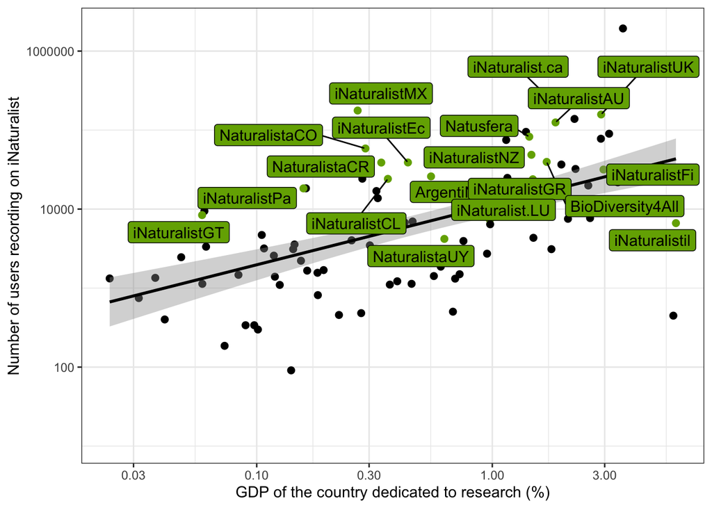

Number of users recording on iNaturalist vs % of the country’s GDP dedicated to research

```r
## users
ggplot(data_variables %>%
         mutate(site_on_iNat = ifelse(!is.na(site_id), 'yes', 'no')),
       aes(gdp_research,n_users, label = site_name)) +
  geom_point(aes(col=site_on_iNat), size=2, show.legend = F) +
  scale_color_manual(values = c('black', '#74AC00')) +
  geom_smooth(method='lm', colour = 'black') +
  geom_label_repel(aes(fill=site_on_iNat),
                   colour = "black", #fontface = "bold",
                   segment.color = 'black',
                   show.legend = F, max.overlaps= Inf) +
  scale_fill_manual(values = c('#F7F7F7', '#74AC00')) +
  labs(x='GDP of the country dedicated to research (%)',
       y='Number of users recording on iNaturalist') +
  scale_x_log10() + scale_y_log10() +
  theme_bw()
```

## Modelling

```r
data_regressions <- data_variables %>%
  filter(country_code != 'US') %>%
  mutate(has_site = ifelse(!is.na(site_name), 1, 0)) %>%
  mutate(n_gbif_inat = n_records_gbif_iNat/n_records_inat) %>%
  dplyr::select(country_code, n_records_inat, n_gbif_inat, n_users, n_taxa,
                area, gdp, gdp_research, pop, latitude, has_site) %>%
  filter(!is.na(gdp_research) & !is.na(latitude)) %>% # remove NAs
  mutate(log_n_records_inat = log(n_records_inat),
         log_n_users = log(n_users),
         log_n_taxa = log(n_taxa),
         log_area = log(area),
         log_pop = log(pop),
         log_gdp = log(gdp))

###

data_regressions %>%
  select(area, gdp, gdp_research,
         pop, latitude, has_site) %>%
  cor() %>%
  kableExtra::kbl(digits=3, format.args = list(big.mark = ',')) %>%
  kableExtra::kable_material('striped')
```

|  | area | gdp | gdp_research | pop | latitude | has_site |
| --- | --- | --- | --- | --- | --- | --- |
| area | 1.000 | 0.020 | 0.072 | 0.423 | -0.106 | 0.196 |
| gdp | 0.020 | 1.000 | 0.585 | -0.143 | 0.355 | 0.185 |
| gdp_research | 0.072 | 0.585 | 1.000 | 0.068 | 0.359 | 0.126 |
| pop | 0.423 | -0.143 | 0.068 | 1.000 | -0.037 | -0.078 |
| latitude | -0.106 | 0.355 | 0.359 | -0.037 | 1.000 | -0.308 |
| has_site | 0.196 | 0.185 | 0.126 | -0.078 | -0.308 | 1.000 |

## Random forest

### Data

```r
data_regressions <- data_regressions %>%
  select(!starts_with('log'))
```

### Functions

```r
model_iNat_RF <- function(data_df, explanatory_variable, skip_vars) {
  # random forest
  set.seed(123) # useful to do the same split for spatial cross-validation
  data_split <- initial_split(data_df, prop = 3/4,
                              strata = !!sym(explanatory_variable))
  data_train <- training(data_split)
  data_test <- testing(data_split) # for estimating performance later

  # recipe
  rf_recipe <- recipe(formula = as.formula(paste(explanatory_variable,
                                                 '~ .')),
                      data = data_train) %>%
    update_role(country_code, new_role = 'ID') %>%
    update_role(all_of(skip_vars), new_role = 'skip') %>%
    step_normalize(all_predictors())

  # define model
  rf_model <- rand_forest(trees = 1000,
                          min_n = tune(), # to figure out the right value
                          mtry = tune()   # to figure out the right value
  ) %>%
    set_mode('regression') %>%
    set_engine('ranger')

  # workflow
  rf_workflow <- workflow() %>%
    add_recipe(rf_recipe) %>%
    add_model(rf_model)

  ### create random folds for tunning
  set.seed(234)
  random_folds <- vfold_cv(data_train, v = 5)

  # num of predictors in the data minus siteID, geometry and the explanatory variable
  n_mtry <- length(data_train)-3

  # grid for tunning
  rf_grid <- grid_regular(
    mtry(range = c(1, n_mtry)), # how many predictors are taken
    min_n(range = c(2,20)) # minimal node size
  )

  # tune model on random blocks
  set.seed(12345)
  doParallel::registerDoParallel()
  start <- Sys.time()

  rf_tune <- tune_grid(rf_workflow,
                       resamples = random_folds,
                       grid = rf_grid)
  end <- Sys.time()
  print(end-start)

  # visualize tuning result
  plot_tuning_params <- autoplot(rf_tune) +
    theme_bw() +
    ggtitle('Tuning results (trees=1000)')

  # show the best hyperparameters
  # show_best(rf_tune, metric = 'rsq')

  # select the best parameters
  best_params <- rf_tune %>% select_best(metric = 'rmse')

  # finalise workflow with the best parameters
  final_rf_workflow <- rf_workflow %>%
    finalize_workflow(best_params)

  #######################################################

  ###### 2) FIT THE MODEL AND EVALUATE ON TEST DATA

  # last fit (we are fitting our model to the whole training data, and evaluating in the testing data)
  rf_fit <- last_fit(final_rf_workflow, data_split)

  # predictions on the test set
  rf_fit_preds  <- collect_predictions(rf_fit)

  # get R2 from correlation
  rsq_rf_fit_preds <- round((cor(rf_fit_preds$.pred, rf_fit_preds[[explanatory_variable]]))^2, 3)

  # plot observed vs predictide values

  if(explanatory_variable == 'n_records_inat') {
    plot_title = 'Number of records on iNaturalist'
  }
  if(explanatory_variable == 'n_gbif_inat'){
    plot_title = 'Proportion of records from iNaturalist on GBIF'
  }
  if(explanatory_variable == 'n_users'){
    plot_title = 'Number of users recording'
  }
  if(explanatory_variable == 'n_taxa'){
    plot_title = 'Number of taxa recorded'
  }

  plot_test_preds <- ggplot(rf_fit_preds, aes(!!sym(explanatory_variable), .pred)) +
    geom_abline(lty = 2, color = 'orange', lwd=1) +
    geom_point(size=2, alpha = 0.5, col = 'grey35') +
    scale_x_continuous(labels = scales::label_number(scale_cut = c(m = 1000000))) +
    scale_y_continuous(labels = scales::label_number(scale_cut = c(m = 1000000))) +
    labs(x = 'Observed', y = 'Predicted',
         title= plot_title,
         subtitle = bquote(r == .(round(cor(rf_fit_preds$.pred,
                                            rf_fit_preds[[explanatory_variable]]),
                                        2)) ~ ", " ~ R^2 == .(round(rsq_rf_fit_preds, 2))),
         paste0('Pearson correlation: ', round(cor(rf_fit_preds$.pred,
                                                   rf_fit_preds[[explanatory_variable]]), 3))) +
    coord_fixed() +
    ggpubr::theme_classic2()

  # calculate variable importance
  importatnce_rf_model <- rf_model %>%
    finalize_model(best_params) %>%
    set_engine('ranger',
               importance = 'impurity', # variable importance
               seed = 1975)

  # generate dataset for plotting variable importance
  vip_df <- workflow() %>%
    add_recipe(rf_recipe) %>%
    add_model(importatnce_rf_model) %>%
    fit(data_train) %>%
    extract_fit_parsnip() %>%
    vi() %>%
    mutate(Category = case_when(Variable %in% c('gdp', 'gdp_research') ~ 'money',
                                Variable %in% c('area', 'pop') ~ 'structure',
                                Variable %in% c('latitude') ~ 'biodiversity',
                                Variable %in% c('has_site') ~ 'network')) %>%
    mutate(standardise_Importance = (Importance * rsq_rf_fit_preds) / sum(Importance))

  # plot variable importance
  plot_vi <- ggplot(vip_df, aes(x = reorder(Variable, standardise_Importance),
                                y = standardise_Importance,
                                fill = Category)) +
    geom_col(show.legend = F) +
    coord_flip() +
    scale_fill_manual(values = c('money' = '#000000',
                                 'structure' = '#454545',
                                 'biodiversity' = '#bfbfbf',
                                 'network' = '#74ac00')) +
    labs(title = plot_title,
         y = expression('Importance (' * R^2 * ' proportion)'),
         x = '', fill = '',
         subtitle = 'Variable importance') +
    theme_minimal()

  ###########################################################

  # generate dataset for partial dependence plot
  pd_df <- getDataForPartialPlot(vars = c(names(data_df)[-c(1,2,3,4,5)]),
                                 workflow = rf_fit,
                                 data = data_train) %>%
    mutate(Category = case_when(Predictor %in% c('gdp', 'gdp_research') ~ 'money',
                                Predictor %in% c('area', 'pop') ~ 'structure',
                                Predictor %in% c('latitude') ~ 'biodiversity',
                                Predictor %in% c('has_site') ~ 'network')) %>%
    mutate(across(Predictor, ~factor(.,
                                     levels=c('gdp',
                                              'gdp_research',
                                              'area',
                                              'pop',
                                              'latitude',
                                              'has_site'))))

  plot_pd <- ggplot(pd_df, aes(x, y, col=Category)) +
    geom_line(lwd=1.25, alpha=0.8, show.legend = F) +
    scale_colour_manual(values = c('money' = '#000000',
                                 'structure' = '#454545',
                                 'biodiversity' = '#bfbfbf',
                                 'network' = '#74ac00')) +
    scale_x_continuous(labels = scales::label_number(scale_cut = c(m = 1000000))) +
    scale_y_continuous(labels = scales::label_number(scale_cut = c(m = 1000000))) +
    facet_wrap(~Predictor, scales = 'free_x') +
    labs(y= plot_title, col = '',
         subtitle='Partial dependence') +
    ggpubr::theme_pubr() +
    theme(axis.title.x = element_blank())
  #
  # #######################################################
  # ###### 3) SPATIAL CROSS-VALIDATION
  #
  # set.seed(1457)
  #
  # doParallel::registerDoParallel()
  # start <- Sys.time()
  #
  # # fit resamples
  # rf_cv_spatial <- fit_resamples(final_rf_workflow,
  #                                resamples = spatial_folds,
  #                                control = control_resamples(save_pred = TRUE, save_workflow = TRUE))
  #
  # end <- Sys.time()
  # print(end-start)
  #
  # # collect predictions on fitted resamples
  # rf_cv_spatial_preds <- collect_predictions(rf_cv_spatial)
  # rsq_rf_cv_spatial_preds <- round((cor(rf_cv_spatial_preds$.pred,
  #                                       rf_cv_spatial_preds[[explanatory_variable]]))^2, 3)
  #
  #
  # if(explanatory_variable == 'richness_change') {
  #   plot_title_cv = 'Change in species richness (cross-validation)'
  # } else {
  #   plot_title_cv = 'Temporal turnover (cross-validation)'
  # }
  #
  # # plot observed vs predicted
  # plot_cv_spatial_preds <- ggplot(rf_cv_spatial_preds, aes(!!sym(explanatory_variable), .pred)) +
  #   geom_abline(lty = 2, color = 'orange', lwd=1) +
  #   geom_point(size=2, alpha = 0.5, col = 'grey35') +
  #   labs(x = 'Observed', y = 'Predicted',
  #        title= plot_title_cv,
  #        subtitle = bquote(r == .(round(cor(rf_cv_spatial_preds$.pred,
  #                                           rf_cv_spatial_preds[[explanatory_variable]]),
  #                                       2)) ~ ", " ~ R^2 == .(round(rsq_rf_cv_spatial_preds, 2))),
  #        paste0('Pearson correlation: ', round(cor(rf_cv_spatial_preds$.pred,
  #                                                  rf_cv_spatial_preds[[explanatory_variable]]), 3))) +
  #   coord_fixed() +
  #   ggpubr::theme_classic2()
  #

  #######################################################
  ###### 4) RESULTS OF MODEL VALIDATION
  # RMSE: root mean square error
  # rsq: squared correlation
  # cor: Pearson correlation of observed versus predicted values

  final_fit <- fit(final_rf_workflow, data_train)
  train_preds <- predict(final_fit, data_train) %>%
    bind_cols(data_train)

  train_rsq <- rsq(train_preds, truth = !!sym(explanatory_variable), estimate = .pred)
  test_rsq <- rsq(rf_fit_preds, truth = !!sym(explanatory_variable), estimate = .pred)

  rsq_train_test <- bind_rows(train = train_rsq,
                              test  = test_rsq,
                              .id = "dataset")

  return(list(plot_tuning_params, plot_test_preds,
              plot_vi, plot_pd,
              rsq_train_test, vip_df, pd_df))

}

getDataForPartialPlot <- function(vars, workflow, data) {

  if(any(class(data) == 'sf')){
    data <- as_tibble(data)
  }

  map(vars, function(var) {
    partial_dep(extract_workflow(workflow), v = var, X = data)$data %>%
      setNames(c('x', 'y'))
  }) %>%
    bind_rows(.id = 'Predictor') %>%
    mutate(Predictor = vars[as.integer(Predictor)])
}
```

### Total number of records on iNaturalist per country

```r
rf_n_records <- model_iNat_RF(data_df = data_regressions,
              explanatory_variable = 'n_records_inat',
              skip_vars = c('n_gbif_inat',
                            'n_users',
                            'n_taxa'))
```

```
Time difference of 1.997592 secs
```

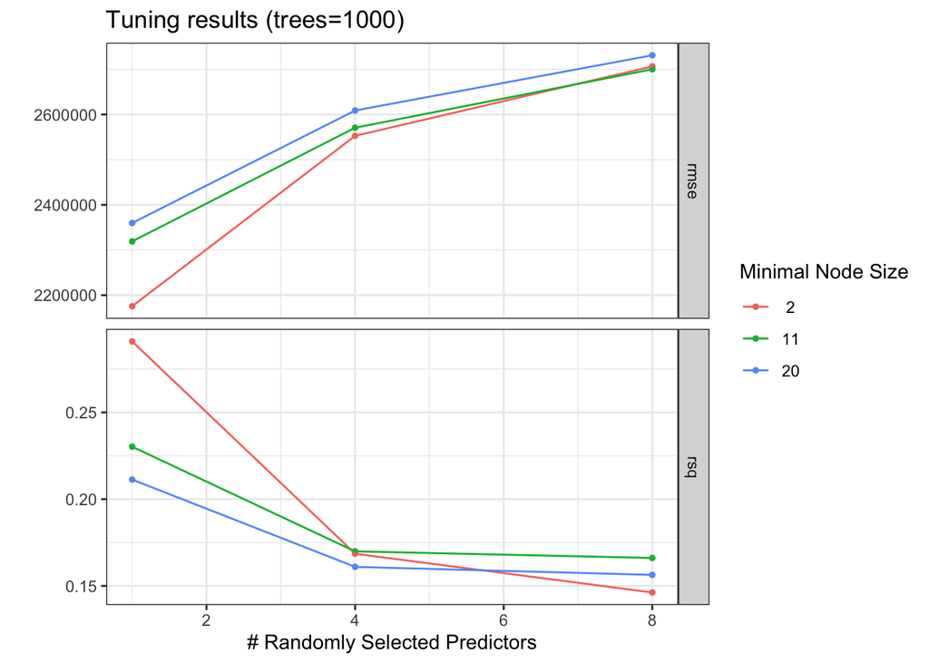

```r
# tuning
rf_n_records[[1]]
```

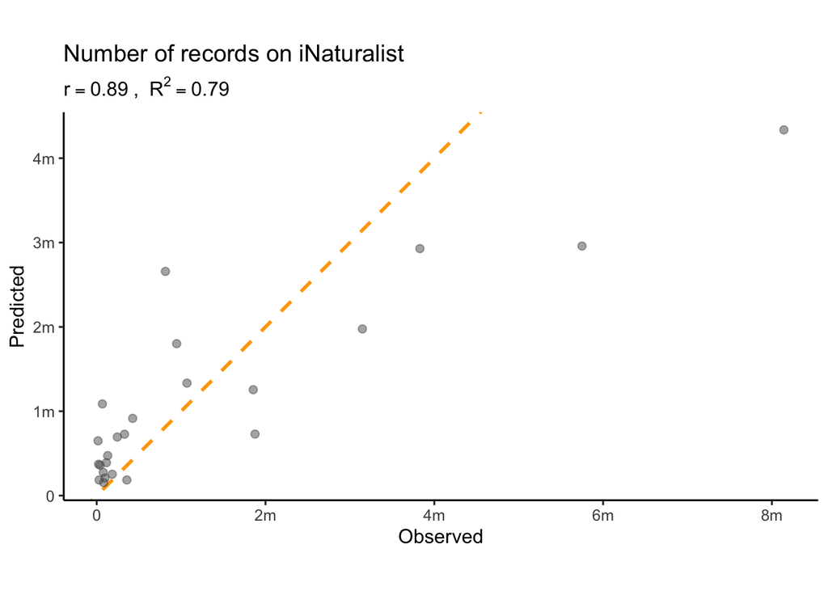

```r
# observed vs predicted
rf_n_records[[2]]
```

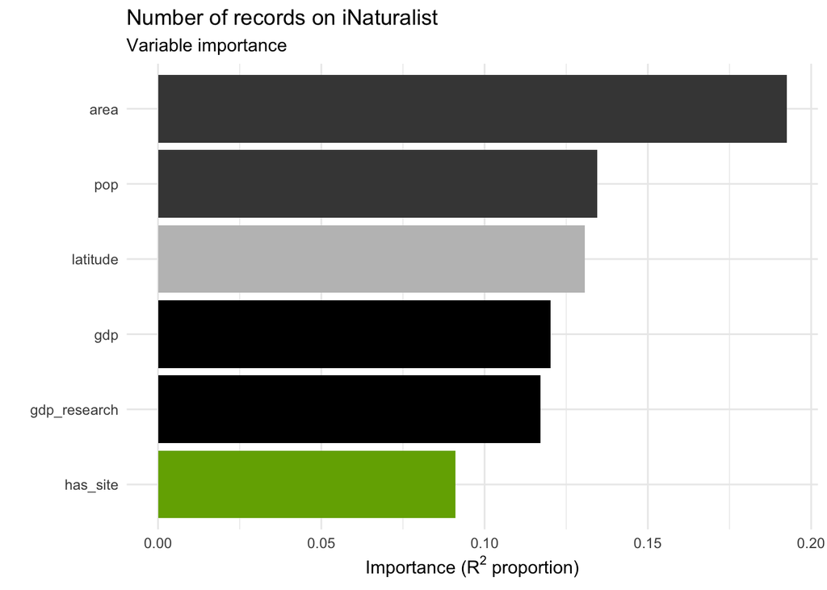

```r
# variable importance
rf_n_records[[3]]
```

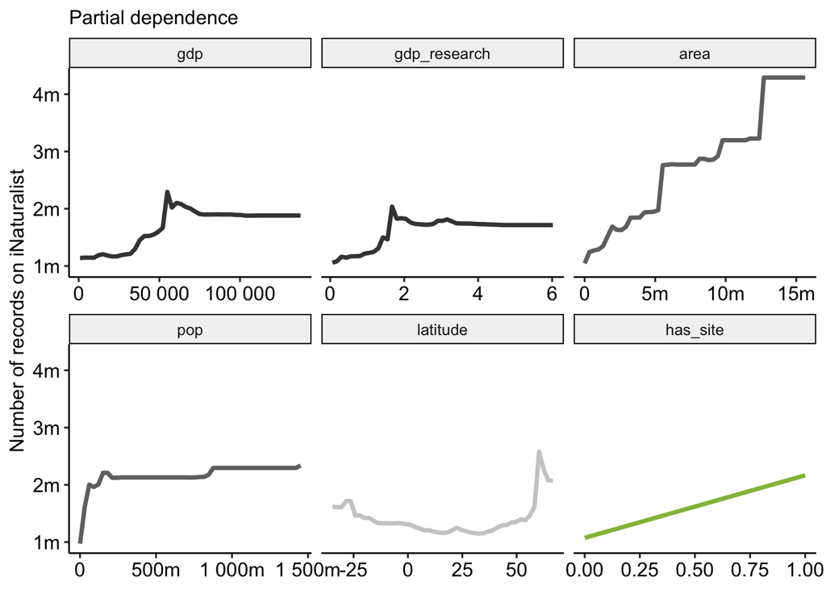

```r
# partial plots
rf_n_records[[4]]
```

```r
# final model metrics
rf_n_records[[5]] %>%
  select(dataset, rsq=.estimate) %>%
  mutate(rsq = round(rsq, 3)) %>%
  rename(`R^2` = rsq) %>%
  knitr::kable() %>% kableExtra::kable_styling(bootstrap_options = c("striped", "hover"))
```

| dataset | R^2 |
| --- | --- |
| train | 0.954 |
| test | 0.786 |

```r
# variable importance
rf_n_records[[6]] %>%
  select(Variable, Importance=standardise_Importance) %>%
  mutate(Importance = round(Importance, 3)) %>%
  rename(`Portion of R^2` = Importance) %>%
  knitr::kable() %>% kableExtra::kable_styling(bootstrap_options = c("striped", "hover"))
```

| Variable | Portion of R^2 |
| --- | --- |
| area | 0.192 |
| pop | 0.135 |
| latitude | 0.131 |
| gdp | 0.120 |
| gdp_research | 0.117 |
| has_site | 0.091 |

### Proportion of records from iNaturalist on GBIF per country

```r
rf_gbif <- model_iNat_RF(data_df = data_regressions,
              explanatory_variable = 'n_gbif_inat',
              skip_vars = c('n_records_inat',
                            'n_users',
                            'n_taxa'))
```

```
Time difference of 1.268984 secs
```

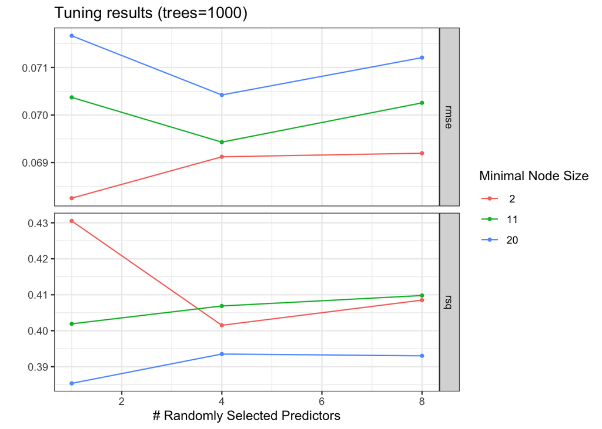

```r
# tuning
rf_gbif[[1]]
```

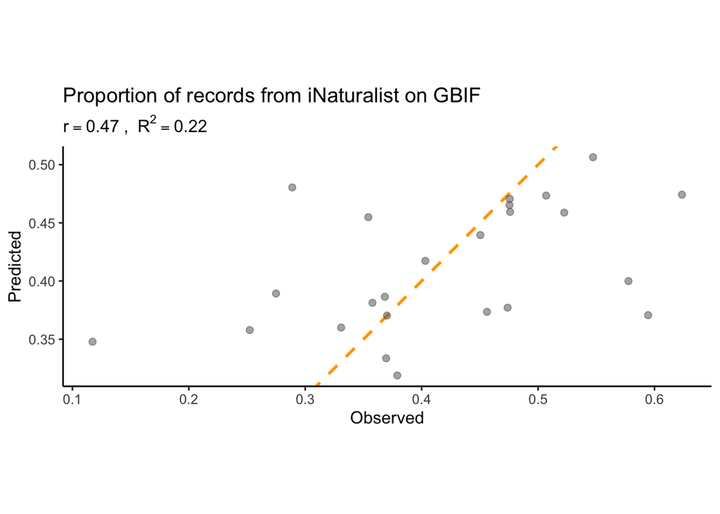

```r
# observed vs predicted
rf_gbif[[2]]
```

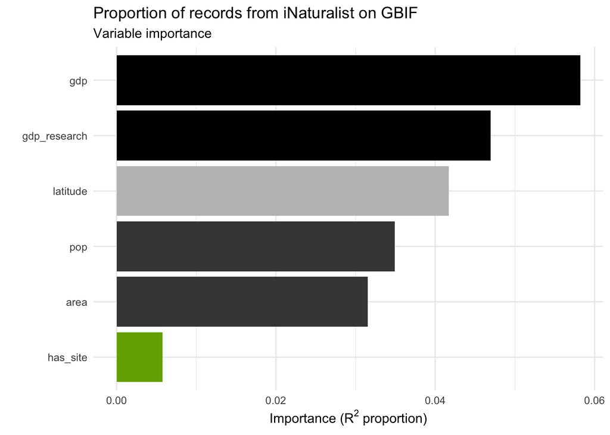

```r
# variable importance
rf_gbif[[3]]
```

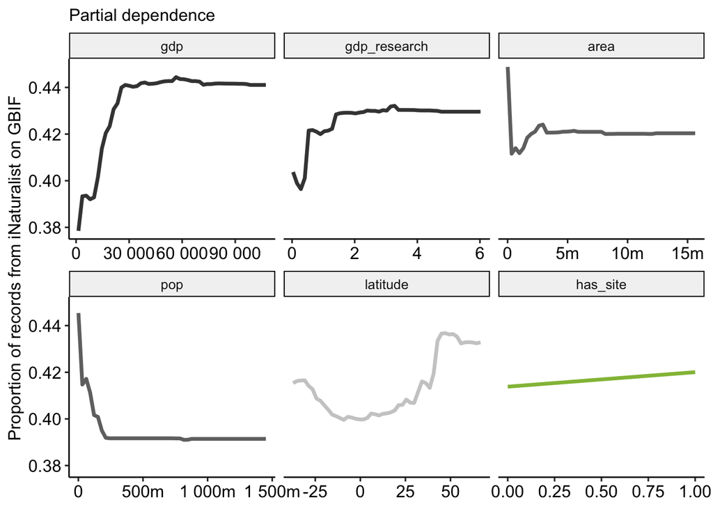

```r
# partial plots
rf_gbif[[4]]
```

```r
# final model metrics
rf_gbif[[5]] %>%
  select(dataset, rsq=.estimate) %>%
  mutate(rsq = round(rsq, 3)) %>%
  rename(`R^2` = rsq) %>%
  knitr::kable() %>% kableExtra::kable_styling(bootstrap_options = c("striped", "hover"))
```

| dataset | R^2 |
| --- | --- |
| train | 0.909 |
| test | 0.219 |

```r
# variable importance
rf_gbif[[6]] %>%
  select(Variable, Importance=standardise_Importance) %>%
  mutate(Importance = round(Importance, 3)) %>%
  rename(`Portion of R^2` = Importance) %>%
  knitr::kable() %>% kableExtra::kable_styling(bootstrap_options = c("striped", "hover"))
```

| Variable | Portion of R^2 |
| --- | --- |
| gdp | 0.058 |
| gdp_research | 0.047 |
| latitude | 0.042 |
| pop | 0.035 |
| area | 0.032 |
| has_site | 0.006 |

### Number of users recording in the country

```r
rf_users <- model_iNat_RF(data_df = data_regressions,
              explanatory_variable = 'n_users',
              skip_vars = c('n_records_inat',
                            'n_gbif_inat',
                            'n_taxa'))
```

```
Time difference of 1.270873 secs
```

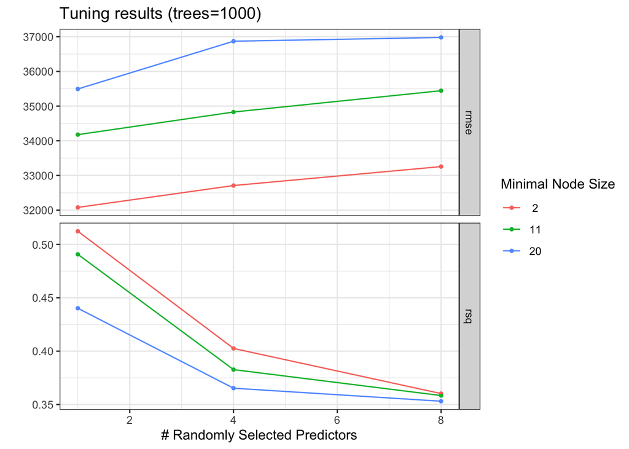

```r
# tuning
rf_users[[1]]
```

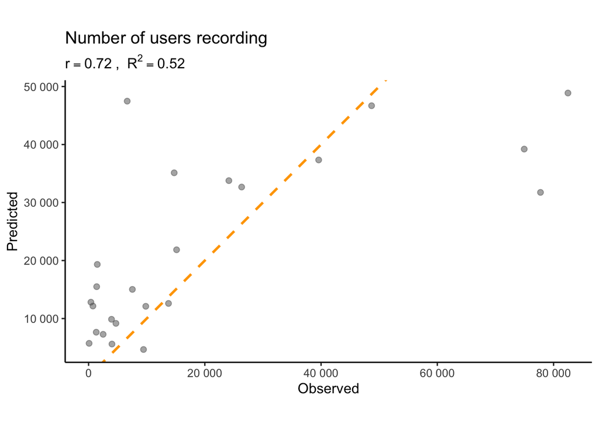

```r
# observed vs predicted
rf_users[[2]]
```

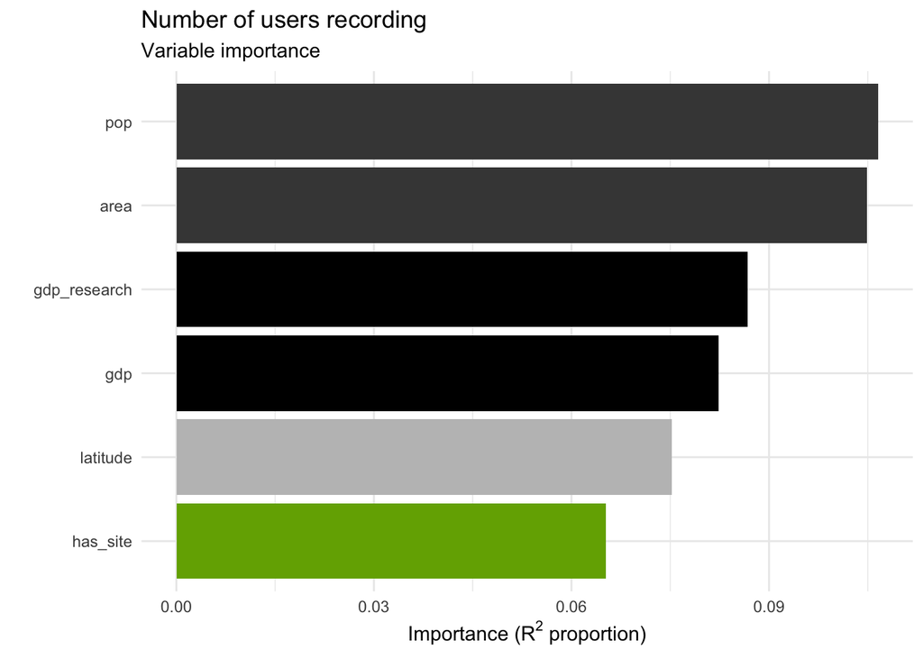

```r
# variable importance
rf_users[[3]]
```

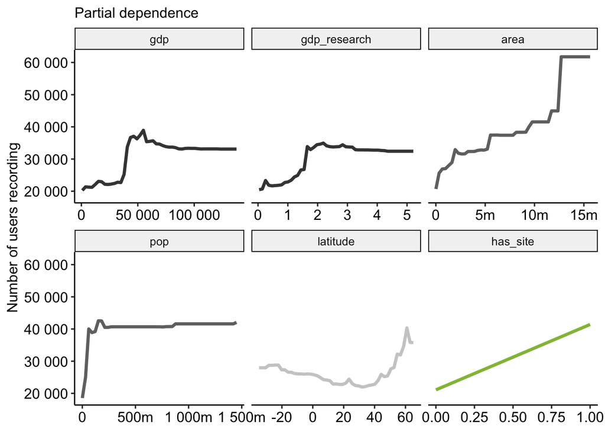

```r
# partial plots
rf_users[[4]]
```

```r
# final model metrics
rf_users[[5]] %>%
  select(dataset, rsq=.estimate) %>%
  mutate(rsq = round(rsq, 3)) %>%
  rename(`R^2` = rsq) %>%
  knitr::kable() %>% kableExtra::kable_styling(bootstrap_options = c("striped", "hover"))
```

| dataset | R^2 |
| --- | --- |
| train | 0.949 |
| test | 0.521 |

```r
# variable importance
rf_users[[6]] %>%
  select(Variable, Importance=standardise_Importance) %>%
  mutate(Importance = round(Importance, 3)) %>%
  rename(`Portion of R^2` = Importance) %>%
  knitr::kable() %>% kableExtra::kable_styling(bootstrap_options = c("striped", "hover"))
```

| Variable | Portion of R^2 |
| --- | --- |
| pop | 0.107 |
| area | 0.105 |
| gdp_research | 0.087 |
| gdp | 0.082 |
| latitude | 0.075 |
| has_site | 0.065 |

### Number of taxa recorded in the country

```r
rf_taxa <- model_iNat_RF(data_df = data_regressions,
              explanatory_variable = 'n_taxa',
              skip_vars = c('n_records_inat',
                            'n_gbif_inat',
                            'n_users'))
```

```
Time difference of 1.252844 secs
```

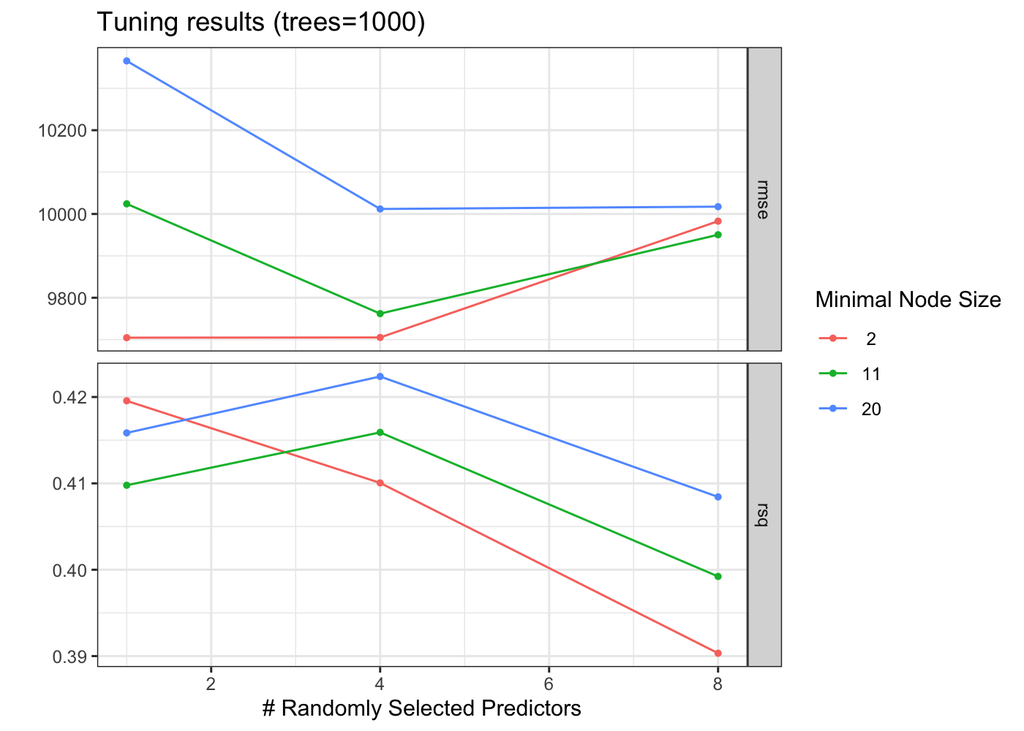

```r
# tuning
rf_taxa[[1]]
```

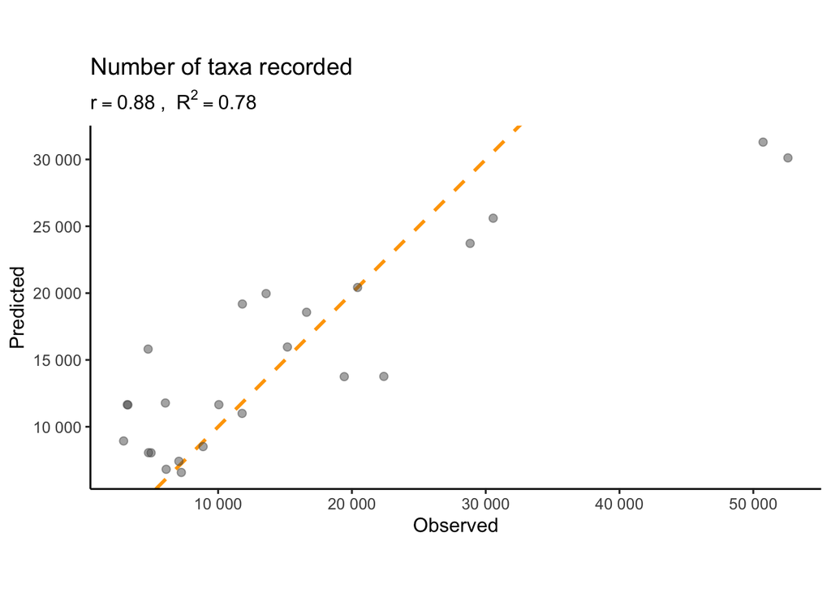

```r
# observed vs predicted
rf_taxa[[2]]
```

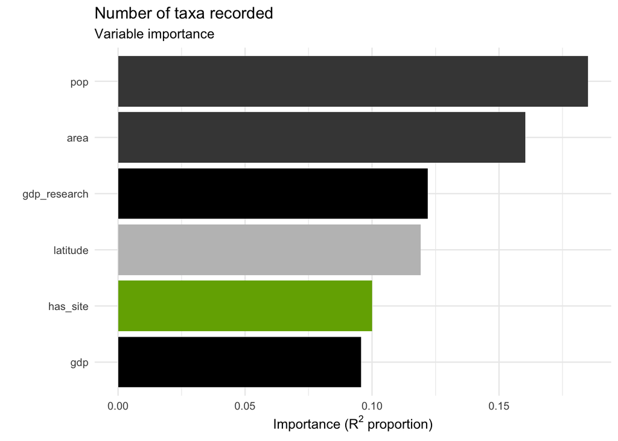

```r
# variable importance
rf_taxa[[3]]
```

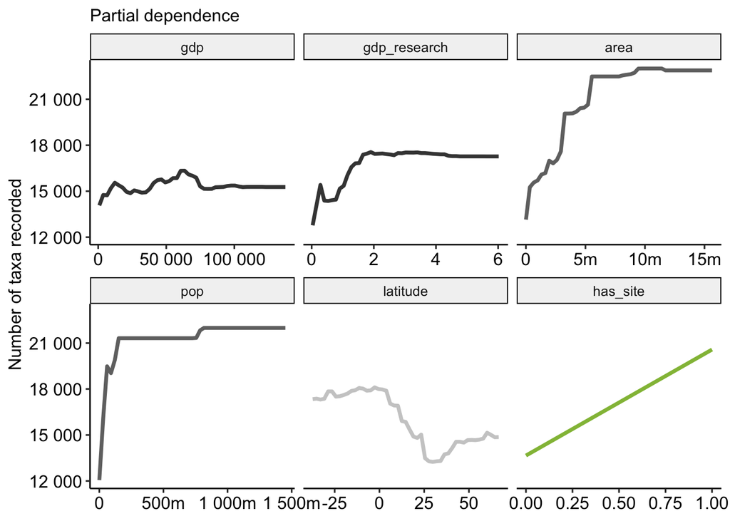

```r
# partial plots
rf_taxa[[4]]
```

```r
# final model metrics
rf_taxa[[5]] %>%
  select(dataset, rsq=.estimate) %>%
  mutate(rsq = round(rsq, 3)) %>%
  rename(`R^2` = rsq) %>%
  knitr::kable() %>% kableExtra::kable_styling(bootstrap_options = c("striped", "hover"))
```

| dataset | R^2 |
| --- | --- |
| train | 0.937 |
| test | 0.782 |

```r
# variable importance
rf_taxa[[6]] %>%
  select(Variable, Importance=standardise_Importance) %>%
  mutate(Importance = round(Importance, 3)) %>%
  rename(`Portion of R^2` = Importance) %>%
  knitr::kable() %>% kableExtra::kable_styling(bootstrap_options = c("striped", "hover"))
```

| Variable | Portion of R^2 |
| --- | --- |
| pop | 0.185 |
| area | 0.160 |
| gdp_research | 0.122 |
| latitude | 0.119 |
| has_site | 0.100 |
| gdp | 0.096 |